# Mixed Model - Animal Model - Pedigree Analysis

Felipe Ferrão  
University of Florida -- Oct 04th, 2018

### Motivation

- Genetic parameters (h2)
- Genetic correlations (Multi-traits models)
- Unbalanced data
- Variance modeling (more complex models, e.g, spatial analysis)
- GxE interaction
- **Ranking genotypes**

### Motivation

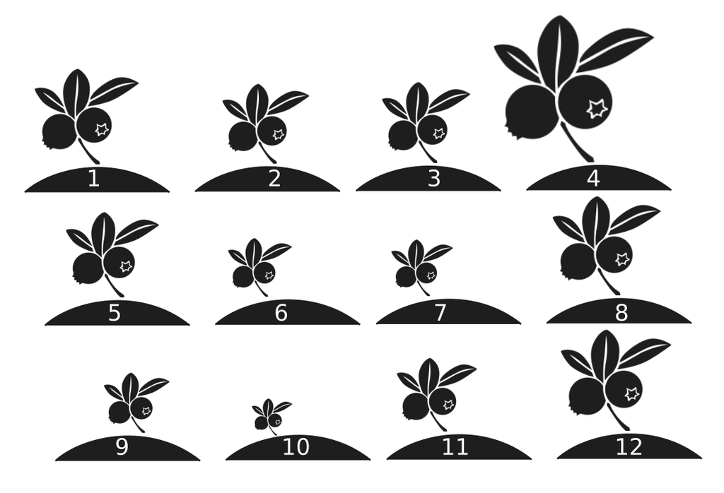

### Example

- Unreplicated test genotypes: each genotype is unique
- Visual selection
- Selecting for berry size
- Advantages and drawbacks?

### Motivation

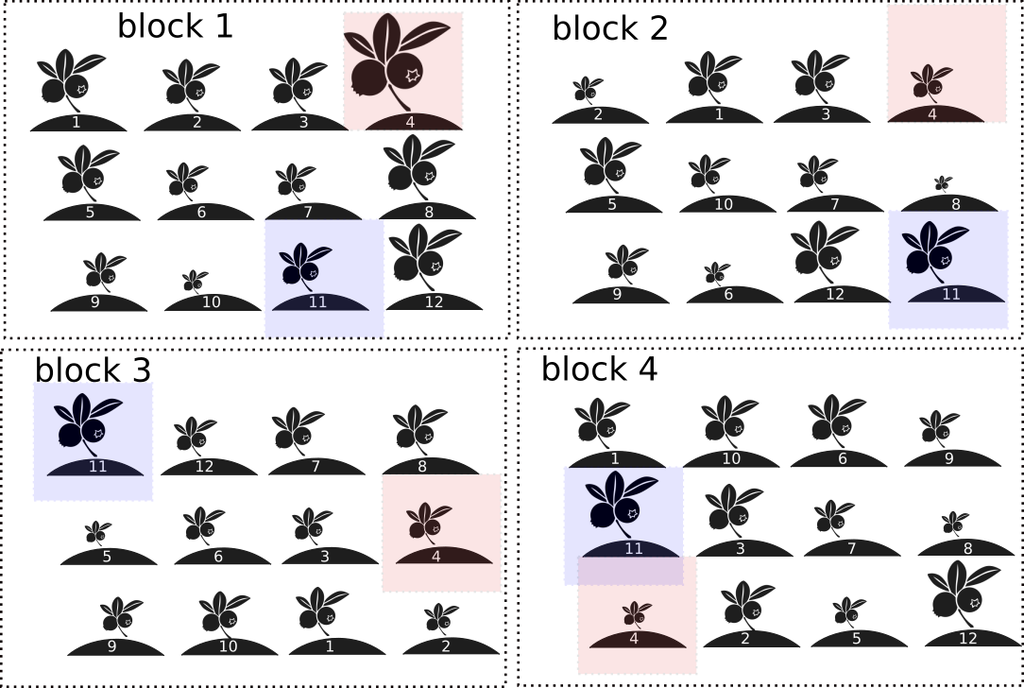

### Replication

- Increasing the precision of estimated means
- Increasing the power of statistical tests
- **Providing an estimate of the experimental error**

### Motivation

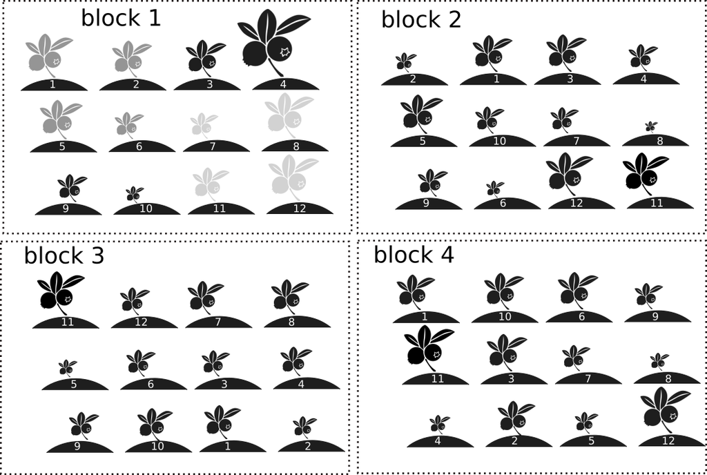

### Genetic motivation to use pedigree

- Genetic data are **non-independent**
- Uses all the information from relatives. Each relative contributes to the estimate of each individual’s BV depending on how genetically close they are
- Predict the **breeding values** for grandparents, parents and progeny in one step
- **More complex genetic models**, such as additive, dominance, paternal and clonal effects
- It provides a **prediction** even if an individual does not have a measured phenotype, as long as one or more relatives are measured

### BLUP

### Statistical advantages

Important points related to the BLUP are incorporated in its name:

- B = **Best** means it maximizes the correlation between true and predicted breeding values or minimizes prediction error variance
- L = **Linear** because predictors are linear functions of observations
- U = **Unbiased** is a desired statistical propriety related to the estimation of realized values for a random variable
- P = **Prediction** involves predicting the true breeding value.

### Motivation

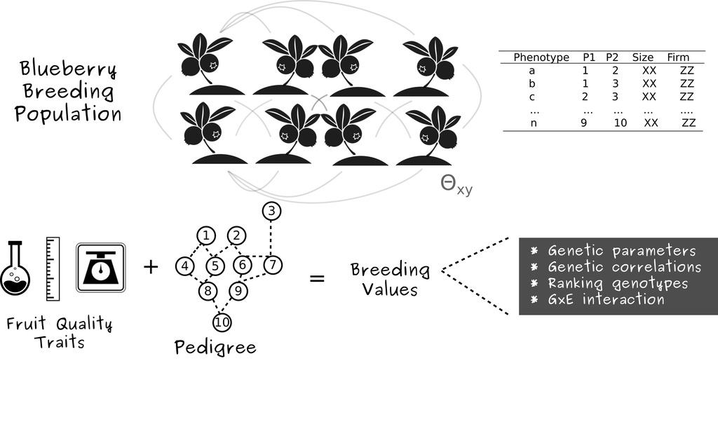

### Pedigree

R packages

- pedigree (`makeA`)
- pedigreemm (`getA`)
- kinship (`kinship`)
- synbreed (`kin`)
- **AGHmatrix** (`Amatrix`)

https://github.com/prmunoz/AGHmatrix

### Pedigree- Example

- Book: Genetic Data Analysis for Plant and Animal Breeding
- [Data set:pine_provenance_pedigree.txt](https://faculty.cnr.ncsu.edu/fikretisik/about/breedingbook/)

```r
ped.new[1:10,]
```

```
   treeid female father
1      10      0      0
2      11      0      0
3      12      0      0
4      13      0      0
5     170     10      0
6     191     10      0
7     192     10      0
8     196     11      0
9     197     11      0
10    198     11      0
```

### Pedigree- Example

- Half-sib families

```r
library(AGHmatrix)
A=Amatrix(ped.new,ploidy=2)
```

```
Verifying conflicting data...
Organizing data...
Your data was chronologically organized with success.
Constructing matrix A using ploidy = 2
Completed! Time = 0.0153  minutes
```

### Pedigree- Example

```r
A[1:10,1:10]
```

```
     10  11 12 13  170  191  192  196  197  198
10  1.0 0.0  0  0 0.50 0.50 0.50 0.00 0.00 0.00
11  0.0 1.0  0  0 0.00 0.00 0.00 0.50 0.50 0.50
12  0.0 0.0  1  0 0.00 0.00 0.00 0.00 0.00 0.00
13  0.0 0.0  0  1 0.00 0.00 0.00 0.00 0.00 0.00
170 0.5 0.0  0  0 1.00 0.25 0.25 0.00 0.00 0.00
191 0.5 0.0  0  0 0.25 1.00 0.25 0.00 0.00 0.00
192 0.5 0.0  0  0 0.25 0.25 1.00 0.00 0.00 0.00
196 0.0 0.5  0  0 0.00 0.00 0.00 1.00 0.25 0.25
197 0.0 0.5  0  0 0.00 0.00 0.00 0.25 1.00 0.25
198 0.0 0.5  0  0 0.00 0.00 0.00 0.25 0.25 1.00
```

### Individual ["Animal"] Model - Example

- Adapted example from the [BGLR](https://cran.r-project.org/web/packages/BGLR/BGLR.pdf) package
- Column as fixed block effects
- Wide format (blocks in each collum)

```r
library(BGLR)
data(wheat)
wheat.Y[1:5,]
```

[output not shown]

### Individual ["Animal"] Model - Example

- reshape2 R package (`melt`)
- Data in the long format

```r
head(pheno)
```

```
    id block      yield
1  775     1  1.6716295
2 2166     1 -0.2527028
3 2167     1  0.3418151
4 2465     1  0.7854395
5 3881     1  0.9983176
6 3889     1  2.3360969
```

```r
tail(pheno)
```

```
          id block     yield
2391 4059227     4 1.7915575
2392 4062993     4 1.6596565
2393 4066585     4 0.5543848
2394 4069736     4 1.8487169
2395 4069854     4 2.6928141
2396 4937014     4 0.3813174
```

### Individual ["Animal"] Model - Example

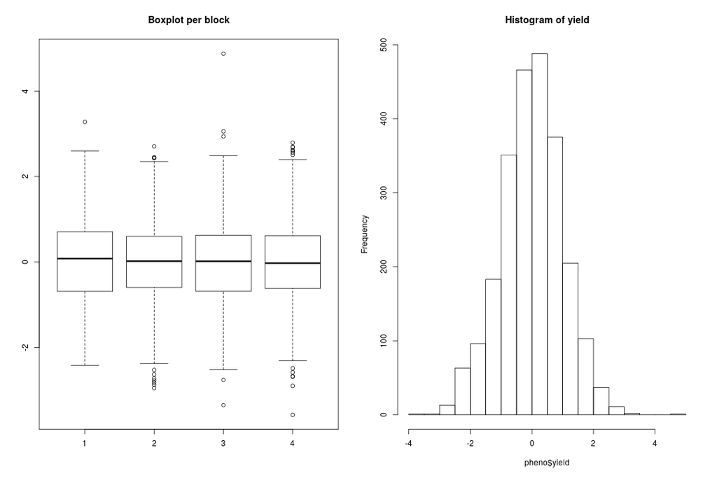

```r
par(mfrow=c(1,2))
boxplot(pheno$yield~pheno$block, main= "Boxplot per block")
hist(pheno$yield, main="Histogram of yield")
```

### Individual ["Animal"] Model - Example

### Traditional and non-free software

- ASRELM
- SAS
- GENSTAT

### Free software and **R packages**

- Bayesian: **BGLR**, **MCMCglmm**, JAGS, Stan
- Frequentist: WOMBAT, **rrBLUP**, **Sommer**, **Regress**, **pedigree**, **NAM**, SELEGEN

### Animal Model - Sommer

- `yield` = response variable
- `block` = fixed effect
- `id` = genotype (lines) random effect
- `wheat.A` = A matrix indexing the random effect (G)

```r
library(sommer)

m1 <- mmer2(yield~ 1 + block,
                random=~g(id),
                G=list(id=as.matrix(wheat.A)),
                silent = T, data=pheno)
```

### Animal Model - Sommer

- Residual diagnostic

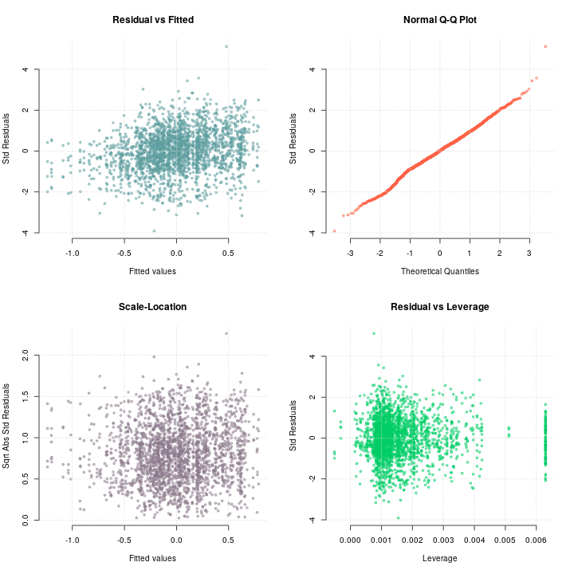

```r
plot(m1)
```

### Animal Model - Sommer

- Variance component
- Heritability

```r
VC = summary(m1)$var.comp.table
h2 = VC[1,1]/(VC[1,1] + VC[2,1]/4)
print(h2)
```

```
[1] 0.359964
```

```r
blups = (m1$u.hat$`g(id)`)
head(sort(blups[,1], decreasing = T))
```

```
 4059227  1630947  1630957   367751   342253  1082612
1.222156 1.211736 1.207867 1.174766 1.170020 1.129599
```